# A Comprehensive Unsupervised Approach to Data Analysis including EDA, Clustering, PCA, and Anomaly Detection with Local Outlier Factor (LOF) in Lung Cancer Patients

Steven Raimondo

2024-11-17

# 1 Introduction

Lung Cancer remains one of the deadliest types of cancer despite the reduction in overall smoking rates over the years. The ever growing awareness of smoking related health issues continues to aid in reducing smoking rates coupled with more health conscience societies we’ve seen a great reduction over the years. However, lung cancer remains a very prevalent and horrible disease that affects millions of individuals with about 1.8 million dying worldwide from the disease in 2022 alone. While, smoking rates have decreased we must take note of the growing world population which still sees thousands of people who don’t smoke get lung cancer every year. The growing availability of more detailed health and environmental data gives researchers more opportunities to explore new areas perhaps previously overlooked to be significant in terms of risk factors for lung cancer.

## 1.1 Background

The lungcancer dataset was obtained via the data science sharing website Kaggle which is a free, peer driven website that allows data scientists to collaborate, enter competitions, and explore different areas of data science. Unfortunately we were unable to obtain the original dataset as Ahmad paper: A new tool to peredict lung cancer based on risk factors link to the original dataset is broken. (Ahmad, 2020). Alas, we thought the dataset was interesting as it looks at other risk factors that play a role in lung cancer. The study the dataset originated from was interested in looking at 462,000 people in China split between areas of high Air Pollution and Low Air pollution to see if there was a significant difference in lung cancer rates. However, we are not aware what individuals from the study the dataset we obtained has in it. The dataset has the risk factor variables for 1,000 lung cancer patients along with their associated level of lung cancer risk.

### 1.1.1 Questions to be Addressed

What risk factors are most strongly associated with developing lung cancer given the dataset?

How effective are clustering techniques like K-Means and Hierarchical clustering in grouping lung cancer risk factors?

How effective are dimension reduction techniques like Principal Component Analysis (PCA) for providing insights into what drives the variability within the data and perhaps associated with lung cancer risk?

How can anomaly detection methods help identify unusual patterns in our dataset?

## 1.2 Working Data Set

The lungcancer dataset was originally comprised of 26 variables and 1000 observations. The subsequent analysis was only performed on the necessary 24 variables after removing index and patient ID. The observations were made up of both categorical and numeric variables. The majority of the variables were on a 1-10 scale, representing different health, lifestyle, and environmental factors believed to contribute to the risk of developing lung cancer. The response variable of interest represented by the variable **Level** which represents the risk level of prediction of lung cancer.

‘Age’: The age of the patient. (Integer)

‘Gender’: The gender of the patient. (1 for male / 2 for female)(Integer)

‘AirPoll’: The level of air pollution exposure of the patient. (Integer)

‘Alcohol’: The level of alcohol use of the patient. (Integer)

‘DustAllergy’: The level of dust allergy of the patient. (Integer)

‘Occu_Hazard’: The level of occupational hazards of the patient. (Integer)

‘GeneticRisk’: The level of genetic risk of the patient. (Integer)

‘ChronicLung’: The level of chronic lung disease of the patient. (Integer)

‘BalanceDiet’: The level of balanced diet of the patient. (Integer)

‘Obesity’: The level of obesity of the patient. (Integer)

‘Smoking’: The level of smoking of the patient. (Integer)

‘PassiveSmoker’: The level of passive smoker of the patient. (Integer)

‘ChestPain’: The level of chest pain of the patient. (Integer)

‘CoughingBlood’: The level of coughing of blood of the patient. (Integer)

‘Fatigue’: The level of fatigue of the patient. (Integer)

‘WeightLoss’: The level of weight loss of the patient. (Integer)

‘ShortBreath’: The level of shortness of breath of the patient. (Integer)

‘Wheezing’: The level of wheezing of the patient. (Integer)

‘Swallow_Diff’: The level of swallowing difficulty of the patient. (Integer)

‘Clubb_Fingers’: The level of clubbing of finger nails of the patient. (Integer)

‘FrequentCold’: The level of frequent colds the patient gets. (Integer)

‘DryCough’: The level of dry cough the patient experiences. (Integer)

‘Snoring’: The level of snoring the patient experiences. (Integer)

‘Level’: The risk level prediction of lung cancer. (Category)

# 2 Methodology

## 2.1 K-Means Clustering

The K-Means clustering algorithm is a statistical procedure that divides a dataset into non-overlapping groups called “Clusters” based on a pre-define similarity where we used as Euclidean distances which is the distance from one observation to the next. The goal of K-Means clustering is to minimize the variation as much as possible **within** a cluster while maximizing the variation **across** clusters. The grouping of which allows us to understand the data more clearly and see what similarities and differences may lie within or across clusters. While, K-Means clustering does not find the optimal number of clusters like we will do via Hierarchical Clustering, it allows for flexibility in choosing how many clusters the analyst wishes to view.

## 2.2 Hierarchical Clustering

We employed another popular clustering approach known as hierarchical clustering. An advantage hierarchical clustering offers over K-Means Clustering is that we don’t need to specify how many clusters we want in the output. Another great advantage hierarchical clustering offers over K-Means is the output results in a tree-based representation known as a dendrogram which is visually easy for the reader to comprehend.

There are two types of hierarchical clusters known as agglomerative and divisive.

**Agglomerative Approach** - Starts with a a single observation in it’s own cluster, and subsequently merges it successfully into a cluster until some stopping criterion is specified, resulting in the final clusters

**Divisive Approach** - The divisive approach is somewhat the opposite of the agglomerative approach where it starts with a single cluster and performs splitting until the specified stopping criterion is met.

## 2.3 Principal Component Analysis (PCA)

Principal Component Analysis (PCA) is a popular and effective unsupervised algorithm statistical technique that reduces the dimensionality of the dataset while preserving as much information as possible. The information we’re interested in, is the variation in the data set. We achieve this by projecting the original p dimensional space to a new set of coordinates where the goal is to transform the data into fewer, more important dimensions. PCA reduces the p variables to m variables where m variables are linear combinations of the original little p variables. In other words, PCA is grouping the variables or features that are highly correlated into more compact variables that are linear combinations of the original variables thus leading to less variables to handle. We show below in our Exploratory Data Analysis (EDA) the correlations between the original variables in the lungcancer dataset and PCA utilizes this to make more compact meaningful variables that capture the variability.

## 2.4 Anomaly Detection

We can utilize certain techniques to help detect anomalies in our data patterns which have a far reaching effect not only on fraud or cybersecurity, but also for areas such as medicine where we might identify certain events or patterns that are not expected leading to more in depth analysis of said anomalies and often gaining values new insight. The primary goal of anomaly detection is rooted in identifying unusual patterns in our data. There are several commonly used methods for anomaly detection which include:

**Statistical Methods:** These techniques detect anomalies based on the data distribution and way to detect them include: the Z-score, Grubbs’ test, and Mahalanobis distance.

**Machine Learning Methods:** Isolation Forest, One-Class SVM, and K-Nearest Neighbors (K-NN) algorithms are all examples of methods that help detect anomalies by learning patterns from normal data.

**Clustering-Based Methods:** We utilized some of these methods in this analysis where we group similar data points, by which we can identify outliers that don’t fit into any clusters, such as K-means and DBSCAN.

**Time-Series-Specific Methods:** Techniques such as: ARIMA, Exponential Smoothing, and LSTM, designed for detecting anomalies in sequential data.

The technique we will employ is the Local Outlier Factor (LOF) which makes use of the density of the neighborhood an observation is in and whether there is a signficant different in densities between that observation and the local “neighborhood”.

# 3 Exploratory Data Analysis

Exploratory Data Analysis (EDA) is a vital initial step in almost any data analysis to help assist with understanding the variables, the relationships variables have with one another, parameters of the dataset, and often offer insights into these factors that be be used as tools later for our analysis. The initial EDA also allows us to explore whether there are data entry errors, outliers, and provides summary statistics. The knowledge gleaned from EDA allows us to perform feature engineering which allows for us to ready the dataset for modelling by performing steps based on our EDA, some examples in this analysis included but not limited to combining highly correlated variables, handling missing values(if needed), scaling, creating new variables, etc.

## 3.1 Missing Values

The 1st action of EDA performed was to examine whether the dataset contains any missing values. We can see below there are no missing values in the lungcancer dataset. Therefore, no interpretation of and possible imputation of any missing values were needed for this analysis.

```r
Missing_Values <- lungcancer[apply(is.na(lungcancer), 1, any), ]
print(Missing_Values)
```

```
##  [1] Age           Gender        AirPoll       Alcohol       DustAllergy
##  [6] Occu_Hazard   GeneticRisk   ChronicLung   BalanceDiet   Obesity
## [11] Smoking       PassiveSmoker ChestPain     CoughBlood    Fatigue
## [16] WeightLoss    ShortBreath   Wheezing      Swallow_Diff  Clubb_Fingers
## [21] FrequentCold  DryCough      Snoring       Level
## <0 rows> (or 0-length row.names)
```

## 3.2 Summary Statistics

Below is the summary statistics of the lungcancer dataset. As previously noted we can see there are no missing values. Additionally, there were a few variables we took special note of while examining the dataset. The medians and means were seen to be very similar, which was expected given the scale the variables are on of 1-10. Additionally, since the dataset utilizes a scale system except for Age, there were no extreme outliers which may be considered a data entry error seen for the scale variables.

**Age** - We can see the age of the patients in dataset has a wide range with the min being 14 years old to the max of 73 years. The difference between these two patients are great not only in terms of age but in terms of physiology and environmental/health exposures. The significant difference is something to keep in mind as we determine what environmental/health exposures contribute significant risk. The median and mean age of the patients were 36 and 37.17 years respectively, indicating a rather young patient population.

**AirPoll** - We see that AirPoll has a wide range of values however, the median and mean of 3 and 3.84 respectively does not show great levels of AirPoll experienced by the patient’s in the dataset.

**Alcohol** - We see that Alcohol was quite high in relation to other risk factors which we know that people who never smoked but consume alcohol heavily are at higher risk of lung cancer (Feringer, et al., 2017)

**DustAllergy** - Another risk factor with elevated values is DustAllergy. Dustallergy and dust in general is something that many people do not think of when thinking of lung cancer as smoking is the most covered risk factor. However, we know that there are many different types of dusts linked to an elevated risk of lung cancer such as two example are wood dust (Bhatti et al., 2011) and silica dust (IARC, 2012)

These summary statistics provide a good starting point of getting acquainted with our dataset and allow us to gain a better understanding of the distribution and variability of our variables and also identify if there are any potential 1st glance issues with our data.

```r
summary(lungcancer)
```

```
##       Age           Gender       AirPoll        Alcohol       DustAllergy
##  Min.   :14.00   Male  :598   Min.   :1.00   Min.   :1.000   Min.   :1.000
##  1st Qu.:27.75   Female:402   1st Qu.:2.00   1st Qu.:2.000   1st Qu.:4.000
##  Median :36.00                Median :3.00   Median :5.000   Median :6.000
##  Mean   :37.17                Mean   :3.84   Mean   :4.563   Mean   :5.165
##  3rd Qu.:45.00                3rd Qu.:6.00   3rd Qu.:7.000   3rd Qu.:7.000
##  Max.   :73.00                Max.   :8.00   Max.   :8.000   Max.   :8.000
##   Occu_Hazard    GeneticRisk    ChronicLung    BalanceDiet       Obesity
##  Min.   :1.00   Min.   :1.00   Min.   :1.00   Min.   :1.000   Min.   :1.000
##  1st Qu.:3.00   1st Qu.:2.00   1st Qu.:3.00   1st Qu.:2.000   1st Qu.:3.000
##  Median :5.00   Median :5.00   Median :4.00   Median :4.000   Median :4.000
##  Mean   :4.84   Mean   :4.58   Mean   :4.38   Mean   :4.491   Mean   :4.465
##  3rd Qu.:7.00   3rd Qu.:7.00   3rd Qu.:6.00   3rd Qu.:7.000   3rd Qu.:7.000
##  Max.   :8.00   Max.   :7.00   Max.   :7.00   Max.   :7.000   Max.   :7.000
##     Smoking      PassiveSmoker     ChestPain       CoughBlood
##  Min.   :1.000   Min.   :1.000   Min.   :1.000   Min.   :1.000
##  1st Qu.:2.000   1st Qu.:2.000   1st Qu.:2.000   1st Qu.:3.000
##  Median :3.000   Median :4.000   Median :4.000   Median :4.000
##  Mean   :3.948   Mean   :4.195   Mean   :4.438   Mean   :4.859
##  3rd Qu.:7.000   3rd Qu.:7.000   3rd Qu.:7.000   3rd Qu.:7.000
##  Max.   :8.000   Max.   :8.000   Max.   :9.000   Max.   :9.000
##     Fatigue        WeightLoss     ShortBreath      Wheezing      Swallow_Diff
##  Min.   :1.000   Min.   :1.000   Min.   :1.00   Min.   :1.000   Min.   :1.000
##  1st Qu.:2.000   1st Qu.:2.000   1st Qu.:2.00   1st Qu.:2.000   1st Qu.:2.000
##  Median :3.000   Median :3.000   Median :4.00   Median :4.000   Median :4.000
##  Mean   :3.856   Mean   :3.855   Mean   :4.24   Mean   :3.777   Mean   :3.746
##  3rd Qu.:5.000   3rd Qu.:6.000   3rd Qu.:6.00   3rd Qu.:5.000   3rd Qu.:5.000
##  Max.   :9.000   Max.   :8.000   Max.   :9.00   Max.   :8.000   Max.   :8.000
##  Clubb_Fingers    FrequentCold      DryCough        Snoring         Level
##  Min.   :1.000   Min.   :1.000   Min.   :1.000   Min.   :1.000   Low   :303
##  1st Qu.:2.000   1st Qu.:2.000   1st Qu.:2.000   1st Qu.:2.000   Medium:332
##  Median :4.000   Median :3.000   Median :4.000   Median :3.000   High  :365
##  Mean   :3.923   Mean   :3.536   Mean   :3.853   Mean   :2.926
##  3rd Qu.:5.000   3rd Qu.:5.000   3rd Qu.:6.000   3rd Qu.:4.000
##  Max.   :9.000   Max.   :7.000   Max.   :7.000   Max.   :7.000
```

While summary statistics provides a good overview of the dataset, we must examine closer to fully understand the structure of our data. We can see via the boxplot below of the patients Age that the oldest patient 73 years old is significantly older than the remaining patients in the dataset.

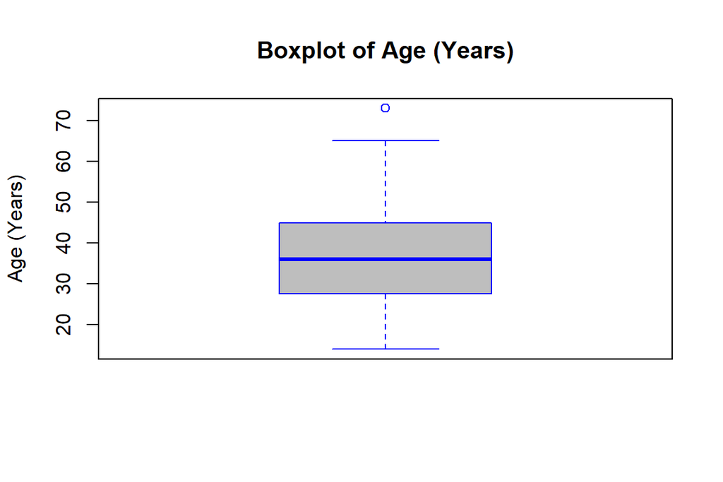

```r
boxplot(lungcancer$Age,
  main= "Boxplot of Age (Years)",
  ylab = "Age (Years)",
  col = "grey",
  border= "blue")
```

A good visual representation of the numerical risk factors that were recorded via a scale of 1-10 is shown below in a boxplot plotting all the variables together. We can see as we states previously there were some variables with a noticeably higher median (DustAllergy) whereas other variables such as fatigue and weightloss, frequentcol, snoring, Airpoll all have lower medians. While it’s important to note the medians we also see the majority of the patients are lower on the fatigue scale than other variables however, the boxplot allows us to still visualize the max for each variable. Overall, this provides a good visualization of the risk factor distributions.

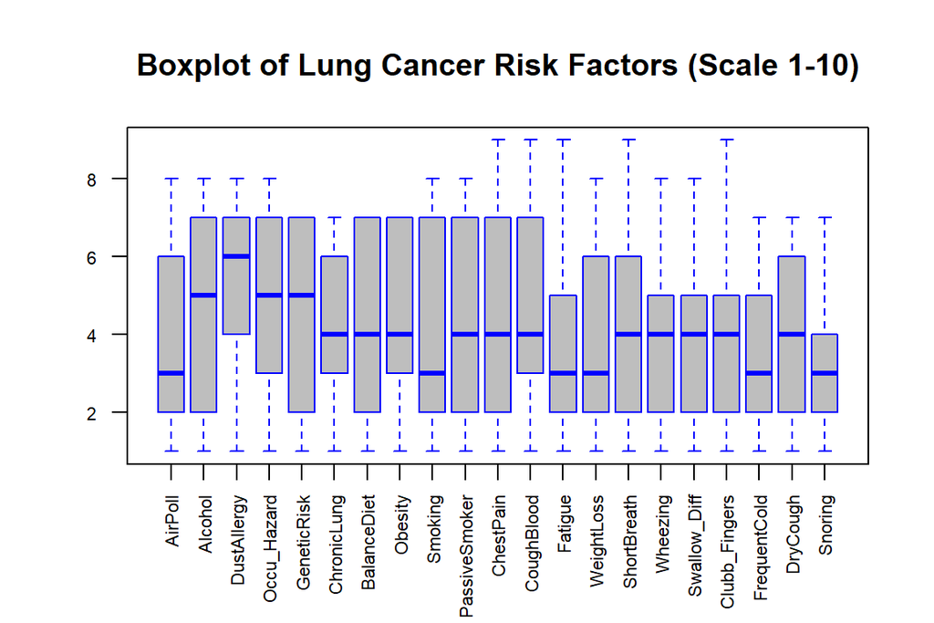

```r
Scale_Varaibles <- lungcancer[, -c(1, 2, 24)]

boxplot(Scale_Varaibles,
  main = "Boxplot of Lung Cancer Risk Factors (Scale 1-10)",
  col = "grey",
  border = "blue", las=2,cex.axis=0.7)
```

While there were only 2 categorical variables present in this dataset, we nonetheless looked at the distribution of the Genders and different risk Levels present in the dataset to determine if there was any imbalance we should take note of.

We can see below that there was a fairly good distribution amongst males and females in this dataset. Additionally, the three levels of lungcancer risk each had a substantial representation where 303 patients made up the low risk, 332 the medium, and 365 in the high risk group.

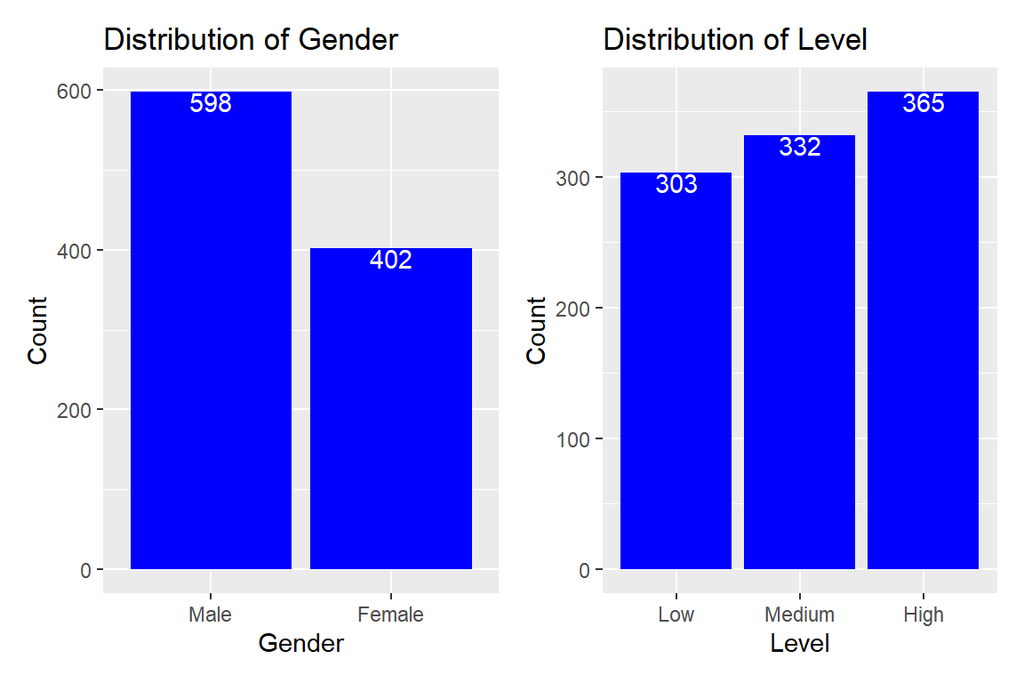

```r
library(ggplot2)
library(patchwork)
plot1 <- ggplot(lungcancer, aes(x = Gender)) +
  geom_bar(fill = "Blue") +
  geom_text(stat = 'count', aes(label = ..count..), vjust = 1, color = "White") +
  labs(title = "Distribution of Gender", x = "Gender", y = "Count")

plot2 <- ggplot(lungcancer, aes(x = Level)) +
  geom_bar(fill = "Blue") +
  geom_text(stat = 'count', aes(label = ..count..), vjust = 1, color = "White") +
  labs(title = "Distribution of Level", x = "Level", y = "Count")

(plot1 + plot2)
```

The next step in our EDA process was to view the scaled variables via density curve to see the distribution layout of each variable. We can see immediately that while we took note the max age of the patients was 73, there is not particularly a great number of patients that are older which again is something to take note of when we’re exploring variables that might be influenced more on exposures some patients have over time. Additionally we see a bimodal distribution in the density curve for GeneticRisk which is interesting as a fair amount of patients either have a lower genetic risk or high genetic risk with very little in the middle.

Some other density curves that are quite interesting include ChronicLung, AirPoll, and DustAllergy where we see a great increase in patient population as the risk increases. While on the otherhand as the risk increases for the variable snoring we see less patients with a high level of snoring.

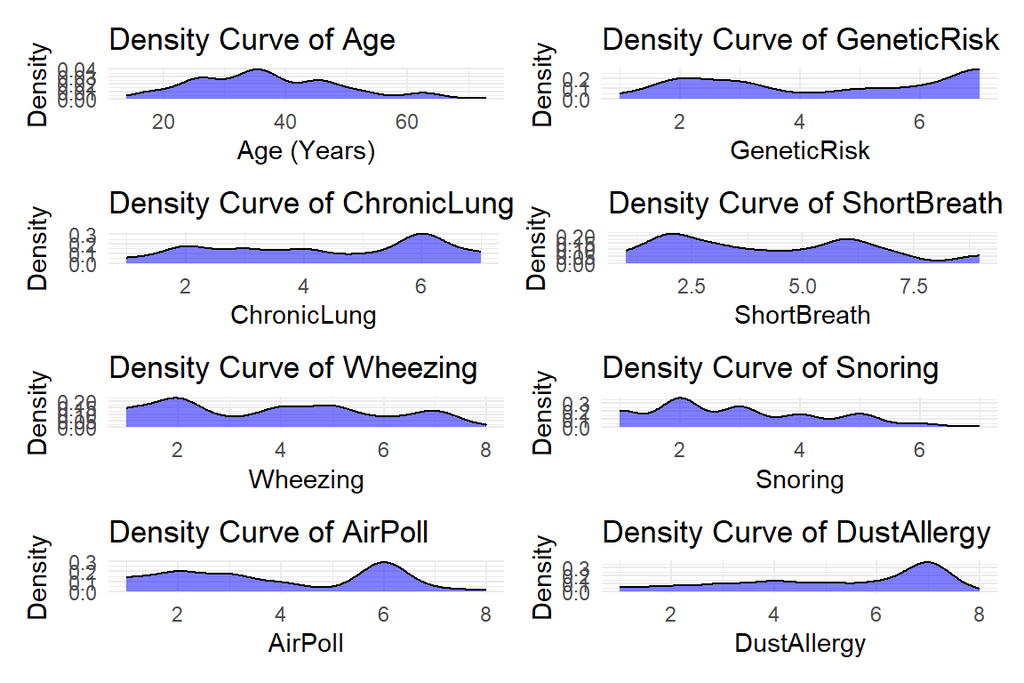

```r
plot3 <- ggplot(lungcancer, aes(x = Age)) +
  geom_density(fill = "blue", alpha = 0.5) +
  labs(title = "Density Curve of Age", x = "Age (Years)", y = "Density") +
  theme_minimal()

plot4 <- ggplot(lungcancer, aes(x = GeneticRisk)) +
  geom_density(fill = "blue", alpha = 0.5) +
  labs(title = "Density Curve of GeneticRisk", x = "GeneticRisk", y = "Density") +
  theme_minimal()

plot5 <- ggplot(lungcancer, aes(x = ChronicLung)) +
  geom_density(fill = "blue", alpha = 0.5) +
  labs(title = "Density Curve of ChronicLung", x = "ChronicLung", y = "Density") +
  theme_minimal()

plot6 <- ggplot(lungcancer, aes(x = ShortBreath)) +
  geom_density(fill = "blue", alpha = 0.5) +
  labs(title = "Density Curve of ShortBreath", x = "ShortBreath", y = "Density") +
  theme_minimal()

plot7 <- ggplot(lungcancer, aes(x = Wheezing)) +
  geom_density(fill = "blue", alpha = 0.5) +
  labs(title = "Density Curve of Wheezing", x = "Wheezing", y = "Density") +
  theme_minimal()

plot8 <- ggplot(lungcancer, aes(x = Snoring)) +
  geom_density(fill = "blue", alpha = 0.5) +
  labs(title = "Density Curve of Snoring", x = "Snoring", y = "Density") +
  theme_minimal()

plot9 <- ggplot(lungcancer, aes(x = AirPoll)) +
  geom_density(fill = "blue", alpha = 0.5) +
  labs(title = "Density Curve of AirPoll", x = "AirPoll", y = "Density") +
  theme_minimal()

plot10 <- ggplot(lungcancer, aes(x = DustAllergy)) +
  geom_density(fill = "blue", alpha = 0.5) +
  labs(title = "Density Curve of DustAllergy", x = "DustAllergy", y = "Density") +
  theme_minimal()

(plot3 + plot4) / (plot5 + plot6) / (plot7 + plot8) / (plot9 + plot10)
```

The next set of density curves we looked at were grouped more in terms of lifestyle factors i.e. Smoking, PassiveSmoker, Alcohol, etc. We see more bimodal curves from Smoking, BalanceDiet and a bit lesser extent of Alcohol and Obesity. It appears a fair amount of the variables have patients on either side of the spectrum when looking at risk factors. Additionally, we see the density curve drop at the higher upper limit for weight loss while the level for obesity rises indicating that individuals who are obese have a higher risk while those who tend to lose weight have a lower risk. Lastly, we see that Occu_Hazard is relatively level until the peak which just so happens to be in the upper range of risk level indicating that the majority of individuals that do have Occu_Hazards show an increased risk level of developing lung cancer.

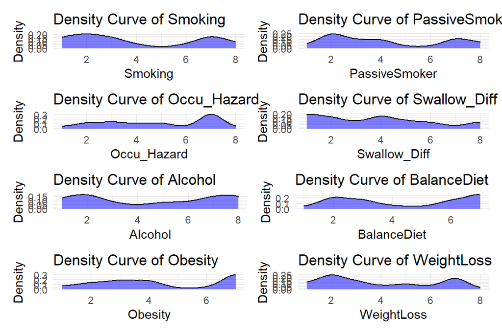

```r
plot11 <- ggplot(lungcancer, aes(x = Smoking)) +
  geom_density(fill = "blue", alpha = 0.5) +
  labs(title = "Density Curve of Smoking", x = "Smoking", y = "Density") +
  theme_minimal()

plot12 <- ggplot(lungcancer, aes(x = PassiveSmoker)) +
  geom_density(fill = "blue", alpha = 0.5) +
  labs(title = "Density Curve of PassiveSmoker", x = "PassiveSmoker", y = "Density") +
  theme_minimal()

plot13 <- ggplot(lungcancer, aes(x = Occu_Hazard)) +
  geom_density(fill = "blue", alpha = 0.5) +
  labs(title = "Density Curve of Occu_Hazard", x = "Occu_Hazard", y = "Density") +
  theme_minimal()

plot14 <- ggplot(lungcancer, aes(x = Swallow_Diff)) +
  geom_density(fill = "blue", alpha = 0.5) +
  labs(title = "Density Curve of Swallow_Diff", x = "Swallow_Diff", y = "Density") +
  theme_minimal()

plot15 <- ggplot(lungcancer, aes(x = Alcohol)) +
  geom_density(fill = "blue", alpha = 0.5) +
  labs(title = "Density Curve of Alcohol", x = "Alcohol", y = "Density") +
  theme_minimal()

plot16 <- ggplot(lungcancer, aes(x = BalanceDiet)) +
  geom_density(fill = "blue", alpha = 0.5) +
  labs(title = "Density Curve of BalanceDiet", x = "BalanceDiet", y = "Density") +
  theme_minimal()

plot17 <- ggplot(lungcancer, aes(x = Obesity)) +
  geom_density(fill = "blue", alpha = 0.5) +
  labs(title = "Density Curve of Obesity", x = "Obesity", y = "Density") +
  theme_minimal()

plot18 <- ggplot(lungcancer, aes(x = WeightLoss)) +
  geom_density(fill = "blue", alpha = 0.5) +
  labs(title = "Density Curve of WeightLoss", x = "WeightLoss", y = "Density") +
  theme_minimal()

(plot11 + plot12) / (plot13 + plot14) / (plot15 + plot16) / (plot17 + plot18)
```

The last set of density curves were grouped based on more of physical characteristics we might see with patients experiencing lung cancer symptoms. Again, we see some very pronounced bimodal curves and lesser ones. The fact we don’t know what the status of the patients are in the dataset hinders us as there may be some patients that are further along in their disease and are experiencing certain symptoms while others have not. The variable Fatigue for example is a variable that’s very susceptible to the stage the patient is in their disease. We see the majority of the patients have a lower amount of fatigue as a while other patients have a very high level of Fatigue. The density curve for ChestPain is very telling as a hallmark sign of lungcancer is chestpain which individuals should take particular note of if they do experience chest pain.

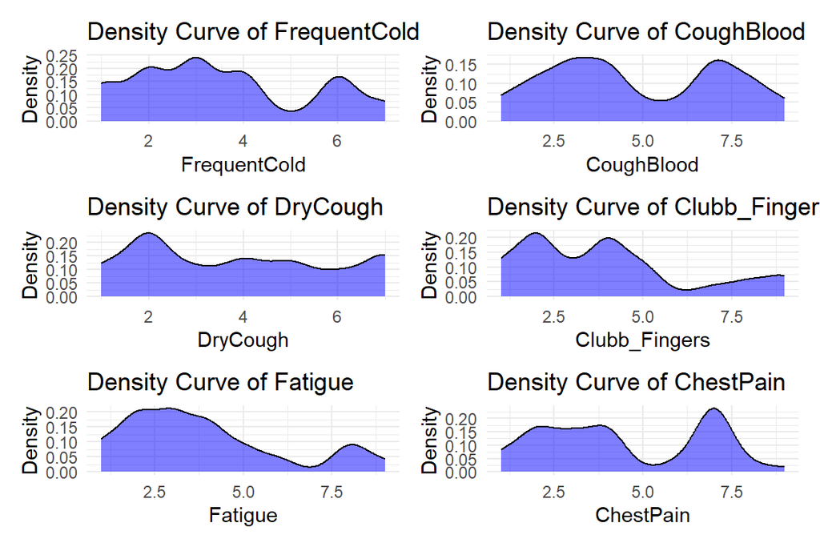

```r
plot19 <- ggplot(lungcancer, aes(x = FrequentCold)) +
  geom_density(fill = "blue", alpha = 0.5) +
  labs(title = "Density Curve of FrequentCold", x = "FrequentCold", y = "Density") +
  theme_minimal()

plot20 <- ggplot(lungcancer, aes(x = CoughBlood)) +
  geom_density(fill = "blue", alpha = 0.5) +
  labs(title = "Density Curve of CoughBlood", x = "CoughBlood", y = "Density") +
  theme_minimal()

plot21 <- ggplot(lungcancer, aes(x = DryCough)) +
  geom_density(fill = "blue", alpha = 0.5) +
  labs(title = "Density Curve of DryCough", x = "DryCough", y = "Density") +
  theme_minimal()

plot22 <- ggplot(lungcancer, aes(x = Clubb_Fingers)) +
  geom_density(fill = "blue", alpha = 0.5) +
  labs(title = "Density Curve of Clubb_Fingers", x = "Clubb_Fingers", y = "Density") +
  theme_minimal()

plot23 <- ggplot(lungcancer, aes(x = Fatigue)) +
  geom_density(fill = "blue", alpha = 0.5) +
  labs(title = "Density Curve of Fatigue", x = "Fatigue", y = "Density") +
  theme_minimal()

plot24 <- ggplot(lungcancer, aes(x = ChestPain)) +
  geom_density(fill = "blue", alpha = 0.5) +
  labs(title = "Density Curve of ChestPain", x = "ChestPain", y = "Density") +
  theme_minimal()
(plot19 + plot20) / (plot21 + plot22) / (plot23 + plot24)
```

The next step in the EDA process was to look at the risk factors plotted against the two categorical variables Level and Gender.We see across the three levels there is not a significant difference in the boxplots in terms of age which would suggest age by itself is not strong risk factor of age. However, one must keep in mind a lot of these variables like Occu_Hazard, DustAllergy, etc increases naturally as a person gets older due to an additive effect. We see certain variables that intrigued us beforehand in the summary display much higher median scores in the high level group than others like Alcohol, ChronicLung, DustAllergy, and Occu_Hazard. All of these variables display a step pattern from low to high risk increasing in the value. Additionally we can see snoring does not change signficantly across one group level to another.

The 2nd group of boxplots are grouped by gender, as we know that males are at an overall higher risk of developing lung cancer than women (May, et al., 2023). We see there are no risk factors where females have a higher median value than males, at most they are tied for a couple of variables but for the most part men generally have higher risk factor values than women. The type of work must be considered when looking at these differences as men are more likely to be exposed to dust, airpoll, and job hazards.

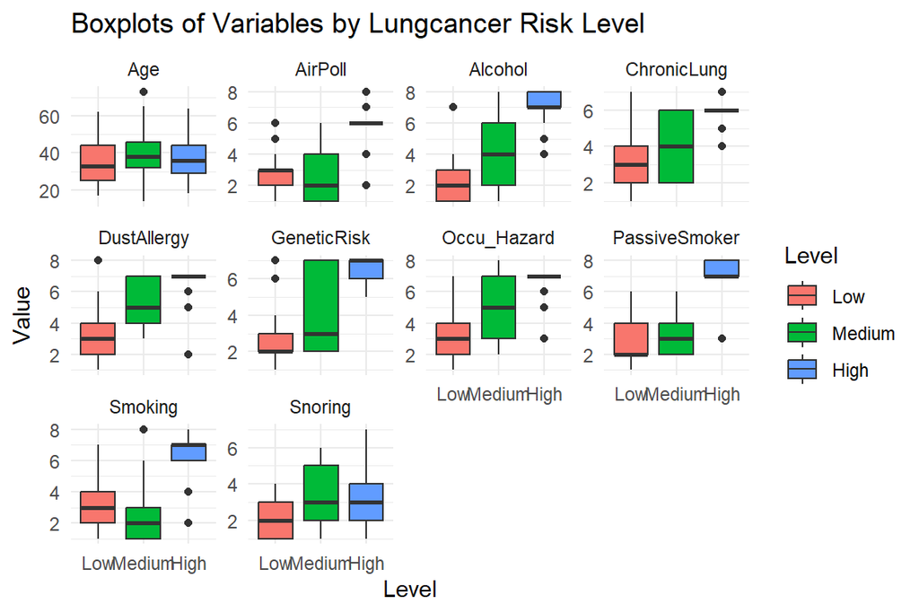

```r
library(ggplot2)
library(tidyr)

lung_long <- lungcancer %>%
  gather(key = "Variable", value = "Value", Age, AirPoll, Alcohol, Alcohol, DustAllergy, Occu_Hazard, GeneticRisk, ChronicLung, Smoking, PassiveSmoker, Snoring)

lung_short <- lungcancer %>%
gather(key = "Variable", value = "Value", BalanceDiet, Obesity, ChestPain, CoughBlood, Fatigue, WeightLoss, ShortBreath, Wheezing, Swallow_Diff, Clubb_Fingers, FrequentCold, DryCough)

ggplot(lung_long, aes(x = Level, y = Value, fill = Level)) +
  geom_boxplot() +
  facet_wrap(~ Variable, scales = "free_y") +
  labs(title = "Boxplots of Variables by Lungcancer Risk Level",
       x = "Level",
       y = "Value") +
  theme_minimal()
```

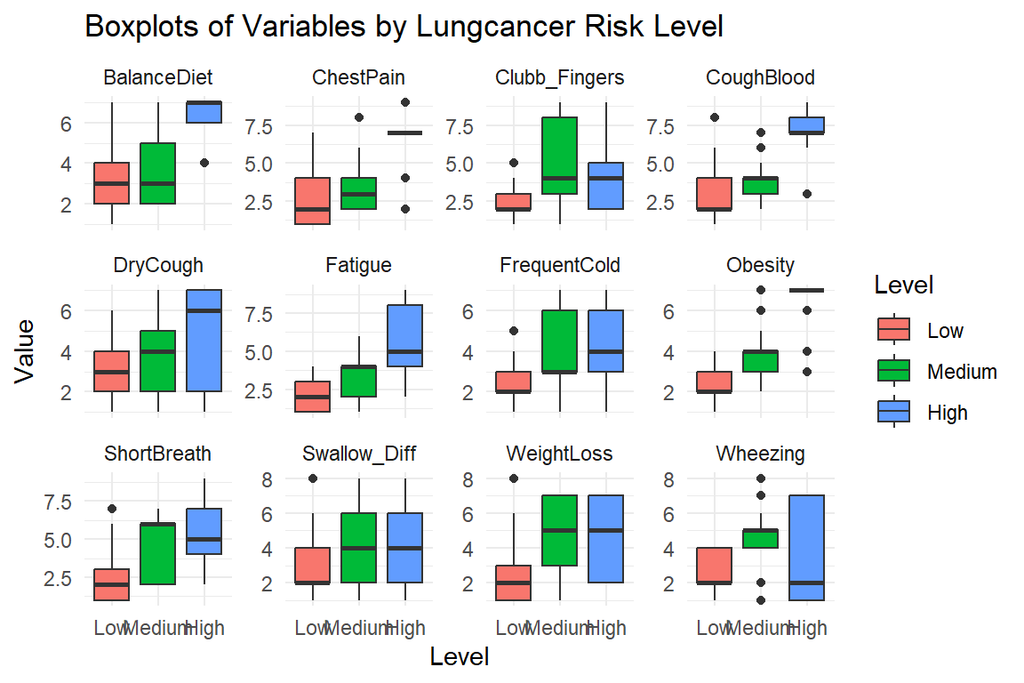

```r
ggplot(lung_short, aes(x = Level, y = Value, fill = Level)) +
  geom_boxplot() +
  facet_wrap(~ Variable, scales = "free_y") +
  labs(title = "Boxplots of Variables by Lungcancer Risk Level",
       x = "Level",
       y = "Value") +
  theme_minimal()
```

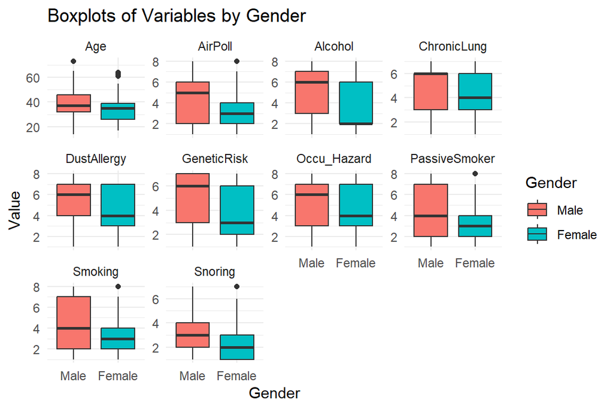

```r
ggplot(lung_long, aes(x = Gender, y = Value, fill = Gender)) +
  geom_boxplot() +
  facet_wrap(~ Variable, scales = "free_y") +
  labs(title = "Boxplots of Variables by Gender",
       x = "Gender",
       y = "Value") +
  theme_minimal()
```

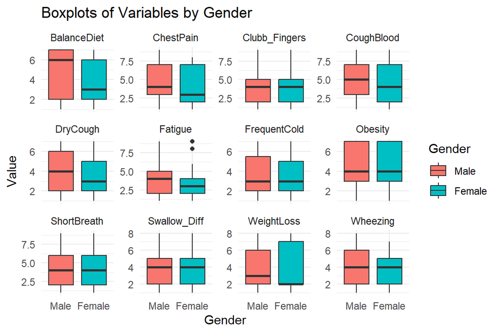

```r
ggplot(lung_short, aes(x = Gender, y = Value, fill = Gender)) +
  geom_boxplot() +
  facet_wrap(~ Variable, scales = "free_y") +
  labs(title = "Boxplots of Variables by Gender",
       x = "Gender",
       y = "Value") +
  theme_minimal()
```

### 3.2.1 Accessing Pairwise Plots

Our next step of EDA involves accessing the pairwise plots for numerical variables in the dataset. The ability to view the correlations between variables will allow us to better understand what sort of redundancies we see amongst the variables. Given that our dataset is quite robust with 22 numeric variables, the ggpairs plots were not very useful in viewing the correlations. However, we’ve also used the cor R function to show us the correlations between the variables.

[figure not shown]

```r
library(GGally)
PairwisePlots = lungcancer[, c(1,3:23)]
ggpairs(PairwisePlots)
```

Below we have the correlations for the numeric variables. However, we want to remove the diagonal (ID) section of the output since they are the same variables.

```r
cor(PairwisePlots)
```

```
##                        Age     AirPoll    Alcohol DustAllergy  Occu_Hazard
## Age            1.000000000  0.09949419  0.1517417  0.03520170  0.062177375
## AirPoll        0.099494194  1.00000000  0.7472926  0.63750350  0.608924458
## Alcohol        0.151741723  0.74729261  1.0000000  0.81864352  0.878785921
## DustAllergy    0.035201697  0.63750350  0.8186435  1.00000000  0.835859771
## Occu_Hazard    0.062177375  0.60892446  0.8787859  0.83585977  1.000000000
## GeneticRisk    0.073150538  0.70527606  0.8772099  0.78790388  0.893048523
## ChronicLung    0.128951642  0.62670091  0.7635758  0.61955592  0.858283853
## BalanceDiet    0.004863499  0.52487291  0.6533519  0.64719683  0.691508821
## Obesity        0.034337163  0.60146750  0.6693116  0.70067582  0.722190745
## Smoking        0.075332578  0.48190161  0.5470346  0.35869058  0.497692577
## PassiveSmoker  0.004907618  0.60676370  0.5925764  0.56000248  0.555310666
## ChestPain      0.012863549  0.58573351  0.7172423  0.63998312  0.775618729
## CoughBlood     0.053006399  0.60782860  0.6676118  0.62529147  0.645946503
## Fatigue        0.095058772  0.21172390  0.2372451  0.33247156  0.267843992
## WeightLoss     0.106945701  0.25801612  0.2078511  0.32175619  0.176225579
## ShortBreath    0.035329285  0.26955773  0.4357853  0.51868168  0.366481599
## Wheezing      -0.095354094  0.05536764  0.1808170  0.30485003  0.178925472
## Swallow_Diff  -0.105832694 -0.08091767 -0.1140732  0.03114127 -0.002853115
## Clubb_Fingers  0.039258302  0.24106478  0.4149921  0.34571423  0.366446760
## FrequentCold  -0.012706476  0.17453909  0.1807778  0.21938921  0.077166008
## DryCough       0.012127598  0.26148864  0.2112772  0.30019510  0.159887039
## Snoring       -0.004699822 -0.02134255  0.1226940  0.05284449  0.022916085
##               GeneticRisk ChronicLung  BalanceDiet    Obesity     Smoking
## Age            0.07315054 0.128951642  0.004863499 0.03433716  0.07533258
## AirPoll        0.70527606 0.626700905  0.524872912 0.60146750  0.48190161
## Alcohol        0.87720989 0.763575773  0.653351895 0.66931156  0.54703463
## DustAllergy    0.78790388 0.619555925  0.647196831 0.70067582  0.35869058
## Occu_Hazard    0.89304852 0.858283853  0.691508821 0.72219074  0.49769258
## GeneticRisk    1.00000000 0.836230827  0.679904853 0.72982608  0.54325927
## ChronicLung    0.83623083 1.000000000  0.622632057 0.60175439  0.57858529
## BalanceDiet    0.67990485 0.622632057  1.000000000 0.70692244  0.64538990
## Obesity        0.72982608 0.601754393  0.706922441 1.00000000  0.48679470
## Smoking        0.54325927 0.578585291  0.645389902 0.48679470  1.00000000
## PassiveSmoker  0.60907129 0.572698231  0.725122761 0.68188885  0.76162150
## ChestPain      0.83175083 0.782646079  0.798206779 0.67315022  0.64792612
## CoughBlood     0.63223641 0.602986717  0.745053763 0.81480477  0.55528945
## Fatigue        0.23053044 0.247697060  0.400677660 0.55278817  0.20002932
## WeightLoss     0.27174268 0.104079762 -0.006543913 0.31349493 -0.21293705
## ShortBreath    0.45820047 0.182425753  0.343623498 0.40620323 -0.02325872
```

[output cut: 60 more lines]

```
## BalanceDiet    0.33199460  0.152676797
## Obesity        0.20061819  0.039422347
## Smoking        0.01010135  0.189054603
## PassiveSmoker  0.12076085  0.247943324
## ChestPain      0.14218015  0.140035648
## CoughBlood     0.14765857  0.087943617
## Fatigue        0.27116684  0.231748331
## WeightLoss     0.18859815 -0.189106497
## ShortBreath    0.49333053 -0.159291086
## Wheezing       0.05438837  0.116182515
## Swallow_Diff  -0.05542807  0.210539865
## Clubb_Fingers  0.30727080 -0.017537310
## FrequentCold   0.51591822  0.335843523
## DryCough       1.00000000  0.176145730
## Snoring        0.17614573  1.000000000
```

Below we can see the top 5 correlation coefficients between the variables. We see there are some highly correlating variables, that might introduce redunancy or noise into any subsequent modelling. Therefore, we’ll explore later certain dimension reduction techniques such as PCA that will reduce the redundancy and noise in our dataset allowing for more effective future modelling.

```r
library(tidyr)
library(dplyr)
cor <- cor(PairwisePlots)
print(cor)
```

```
##                        Age     AirPoll    Alcohol DustAllergy  Occu_Hazard
## Age            1.000000000  0.09949419  0.1517417  0.03520170  0.062177375
## AirPoll        0.099494194  1.00000000  0.7472926  0.63750350  0.608924458
## Alcohol        0.151741723  0.74729261  1.0000000  0.81864352  0.878785921
## DustAllergy    0.035201697  0.63750350  0.8186435  1.00000000  0.835859771
## Occu_Hazard    0.062177375  0.60892446  0.8787859  0.83585977  1.000000000
## GeneticRisk    0.073150538  0.70527606  0.8772099  0.78790388  0.893048523
## ChronicLung    0.128951642  0.62670091  0.7635758  0.61955592  0.858283853
## BalanceDiet    0.004863499  0.52487291  0.6533519  0.64719683  0.691508821
## Obesity        0.034337163  0.60146750  0.6693116  0.70067582  0.722190745
## Smoking        0.075332578  0.48190161  0.5470346  0.35869058  0.497692577
## PassiveSmoker  0.004907618  0.60676370  0.5925764  0.56000248  0.555310666
## ChestPain      0.012863549  0.58573351  0.7172423  0.63998312  0.775618729
## CoughBlood     0.053006399  0.60782860  0.6676118  0.62529147  0.645946503
## Fatigue        0.095058772  0.21172390  0.2372451  0.33247156  0.267843992
## WeightLoss     0.106945701  0.25801612  0.2078511  0.32175619  0.176225579
## ShortBreath    0.035329285  0.26955773  0.4357853  0.51868168  0.366481599
## Wheezing      -0.095354094  0.05536764  0.1808170  0.30485003  0.178925472
## Swallow_Diff  -0.105832694 -0.08091767 -0.1140732  0.03114127 -0.002853115
## Clubb_Fingers  0.039258302  0.24106478  0.4149921  0.34571423  0.366446760
## FrequentCold  -0.012706476  0.17453909  0.1807778  0.21938921  0.077166008
## DryCough       0.012127598  0.26148864  0.2112772  0.30019510  0.159887039
## Snoring       -0.004699822 -0.02134255  0.1226940  0.05284449  0.022916085
##               GeneticRisk ChronicLung  BalanceDiet    Obesity     Smoking
## Age            0.07315054 0.128951642  0.004863499 0.03433716  0.07533258
## AirPoll        0.70527606 0.626700905  0.524872912 0.60146750  0.48190161
## Alcohol        0.87720989 0.763575773  0.653351895 0.66931156  0.54703463
## DustAllergy    0.78790388 0.619555925  0.647196831 0.70067582  0.35869058
## Occu_Hazard    0.89304852 0.858283853  0.691508821 0.72219074  0.49769258
## GeneticRisk    1.00000000 0.836230827  0.679904853 0.72982608  0.54325927
## ChronicLung    0.83623083 1.000000000  0.622632057 0.60175439  0.57858529
## BalanceDiet    0.67990485 0.622632057  1.000000000 0.70692244  0.64538990
## Obesity        0.72982608 0.601754393  0.706922441 1.00000000  0.48679470
## Smoking        0.54325927 0.578585291  0.645389902 0.48679470  1.00000000
## PassiveSmoker  0.60907129 0.572698231  0.725122761 0.68188885  0.76162150
## ChestPain      0.83175083 0.782646079  0.798206779 0.67315022  0.64792612
## CoughBlood     0.63223641 0.602986717  0.745053763 0.81480477  0.55528945
## Fatigue        0.23053044 0.247697060  0.400677660 0.55278817  0.20002932
## WeightLoss     0.27174268 0.104079762 -0.006543913 0.31349493 -0.21293705
## ShortBreath    0.45820047 0.182425753  0.343623498 0.40620323 -0.02325872
```

[output cut: 60 more lines]

```
## BalanceDiet    0.33199460  0.152676797
## Obesity        0.20061819  0.039422347
## Smoking        0.01010135  0.189054603
## PassiveSmoker  0.12076085  0.247943324
## ChestPain      0.14218015  0.140035648
## CoughBlood     0.14765857  0.087943617
## Fatigue        0.27116684  0.231748331
## WeightLoss     0.18859815 -0.189106497
## ShortBreath    0.49333053 -0.159291086
## Wheezing       0.05438837  0.116182515
## Swallow_Diff  -0.05542807  0.210539865
## Clubb_Fingers  0.30727080 -0.017537310
## FrequentCold   0.51591822  0.335843523
## DryCough       1.00000000  0.176145730
## Snoring        0.17614573  1.000000000
```

```r
cor_table <- as.data.frame(as.table(cor))
cor_table <- arrange(filter(cor_table, Freq !=1.0), desc(Freq))
print(head(cor_table,10))
```

```
##           Var1        Var2      Freq
## 1  GeneticRisk Occu_Hazard 0.8930485
## 2  Occu_Hazard GeneticRisk 0.8930485
## 3  Occu_Hazard     Alcohol 0.8787859
## 4      Alcohol Occu_Hazard 0.8787859
## 5  GeneticRisk     Alcohol 0.8772099
## 6      Alcohol GeneticRisk 0.8772099
## 7  ChronicLung Occu_Hazard 0.8582839
## 8  Occu_Hazard ChronicLung 0.8582839
## 9  ChronicLung GeneticRisk 0.8362308
## 10 GeneticRisk ChronicLung 0.8362308
```

# 4 Unsupervised Learning

## 4.1 K-Means Clustering

The first type of unsupervised learning we performed was K-Means clustering which we stated previously will be utilizing euclidean distances to group similar observations. Essentially, our goal is to take the distances and group like observations that have similarities within a cluster and to have observations with differences across clusters. We removed the categorical variables Gender and Level since we’re only interested in looking at the euclidean distances between observations and while the majority of the variables were already on a 1-10 scale, we nonetheless scaled the data to reduce the skewness across the variables. Additionally, the scaling of the variables was not known for this analysis so we must try to reduce any inherit variance or disproportionate distributions for the variables based on how the investigators determined the patient’s level.

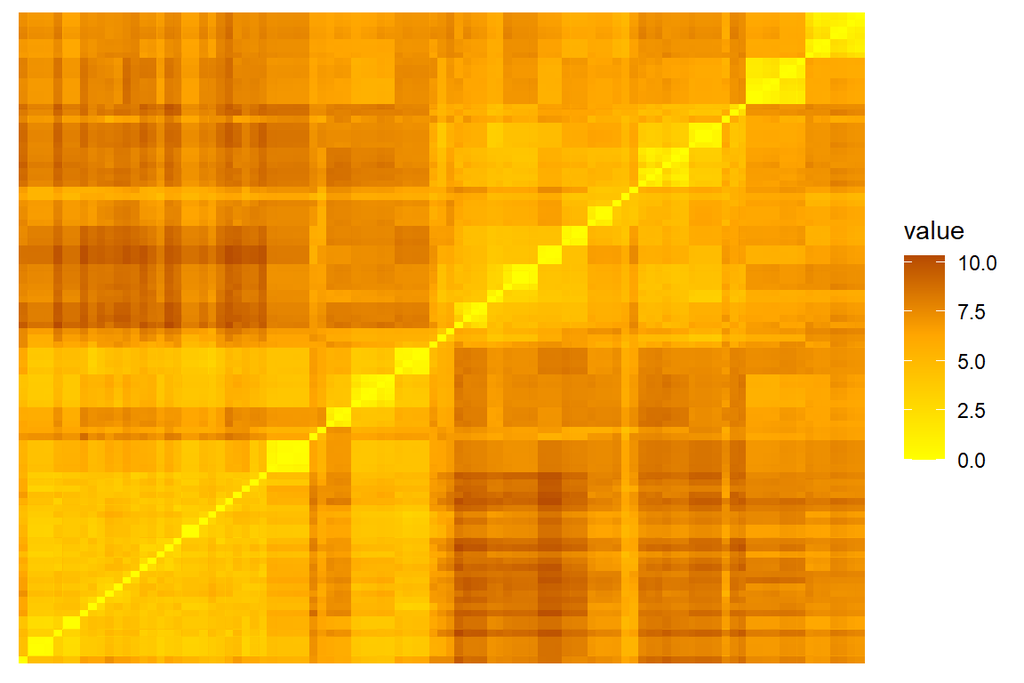

```r
library(factoextra)
set.seed(111)

clust.data = lungcancer[, -c(2, 24)]

scaled.data = as.data.frame(scale(clust.data))

distance = get_dist(scaled.data)

fviz_dist(distance, gradient = list(low = "yellow", mid = "orange", high = "darkred"), show_labels = FALSE)
```

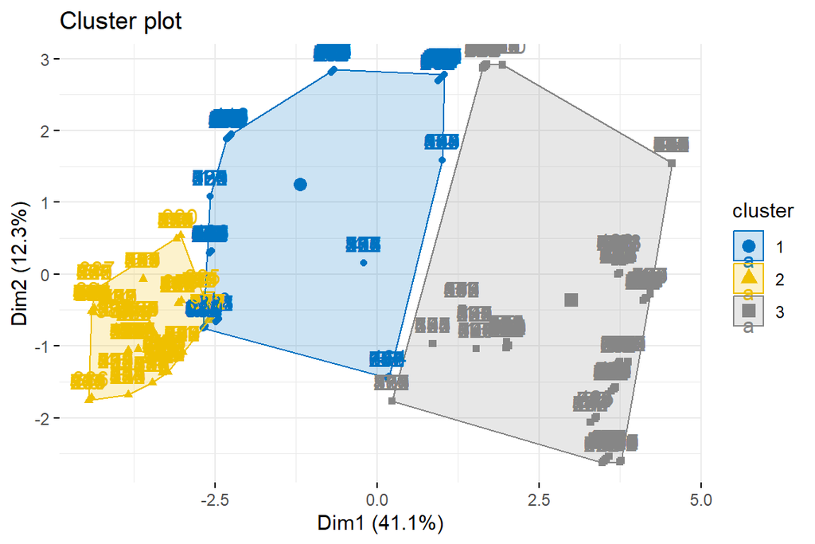

```r
kmeans.result = kmeans(scaled.data, centers = 3)

fviz_cluster(kmeans.result, data = scaled.data, ellipse.type = "convex", palette = "jco", ggtheme = theme_minimal())
```

```r
kmeans.result$centers
```

```
##           Age    AirPoll    Alcohol  DustAllergy Occu_Hazard GeneticRisk
## 1  0.06766081 -0.4676858 -0.2854181 -0.002040099  -0.2230457  -0.2936158
## 2 -0.14294495 -0.6320054 -0.9640879 -1.196531161  -1.0467288  -1.0545392
## 3  0.04429199  0.7105787  0.7966393  0.752295899   0.8066352   0.8589081
##   ChronicLung BalanceDiet    Obesity    Smoking PassiveSmoker  ChestPain
## 1  -0.3389610  -0.6981880 -0.4476878 -0.6830595    -0.5791367 -0.5555486
## 2  -0.8892187  -0.8697149 -0.9807646 -0.4429298    -0.7086421 -0.9037374
## 3   0.7855938   1.0144898  0.9160312  0.7364901     0.8334878  0.9400931
##   CoughBlood     Fatigue  WeightLoss ShortBreath     Wheezing  Swallow_Diff
## 1 -0.6514108 -0.07316136  0.51270245   0.2246850  0.563725198  0.4633338247
## 2 -0.9044596 -0.75832731 -0.68795479  -0.8985159 -0.611937294 -0.4947576744
## 3  1.0048953  0.52502638  0.08759205   0.4130732  0.005634767 -0.0005163947
##   Clubb_Fingers FrequentCold    DryCough     Snoring
## 1    0.62165173    0.1635013 -0.03035993  0.35904556
## 2   -0.60278665   -0.5963305 -0.48301367 -0.44660406
## 3   -0.03899207    0.2644962  0.32351226  0.03926805
```

In order to determine the optimal number of clusters our data should be grouped by we employ the elbow plot technique which allows us to view how much of the variation is reduced for each subsequent cluster. The optimal number of clusters is when an elbow forms in the graph so that the amount of variation that is reduced is greatly decreased as you add more less effective clusters. Hypothetically, we could create as many clusters as there are observations but no information regarding the distribution of the data would gleaned from such an approach so we look for the max info with the least amount of clusters.

We see there this a distinct elbow at 2 clusters.

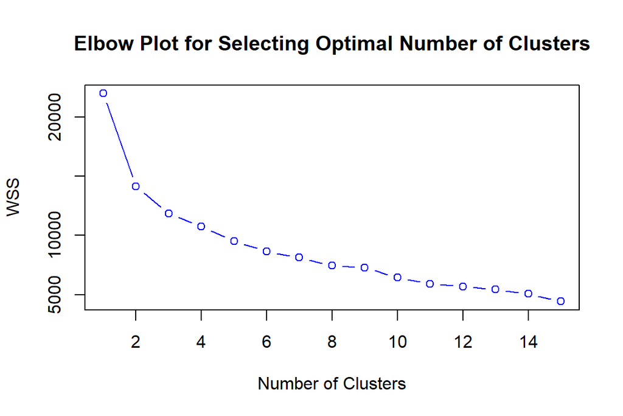

```r
k2 <- kmeans(x = scaled.data,
             centers = 2,
             iter.max = 10,
             nstart = 25,
             algorithm = "Lloyd",
             trace = FALSE)

wss = NULL
K = 15
for (i in 1:K) {
  wss[i] = kmeans(scaled.data, centers = i, iter.max = 1, nstart = 25)$tot.withinss
}

plot(1:K, wss, type = "b",
     col = "blue",
     xlab = "Number of Clusters",
     ylab = "WSS",
     main = "Elbow Plot for Selecting Optimal Number of Clusters")
```

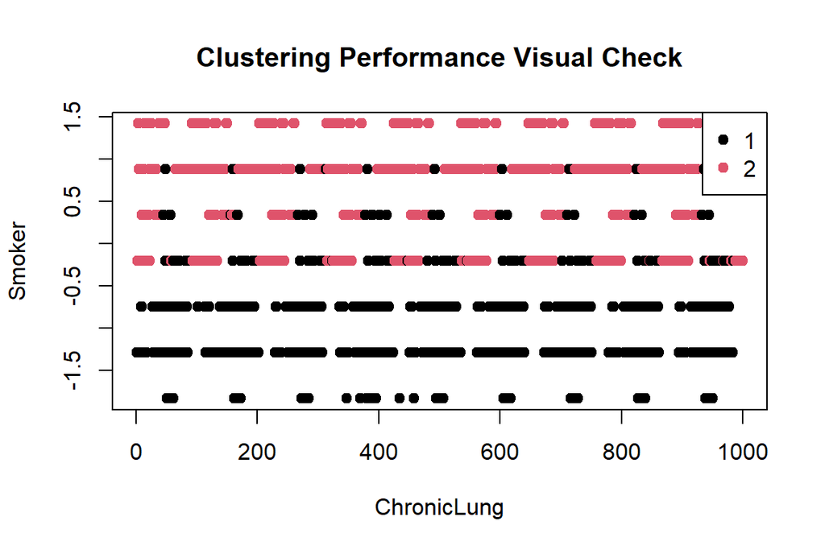

```r
k2 <- kmeans(x = scaled.data,
             centers = 2,
             iter.max = 10,
             nstart = 25,
             algorithm = "Lloyd",
             trace = FALSE)

scaled.data$group = k2$cluster

plot(scaled.data$ChronicLung, scaled.data$Smoker,
     pch = 19,
     col = factor(scaled.data$group),
     xlab = "ChronicLung",
     ylab = "Smoker",
     main = "Clustering Performance Visual Check")

legend("topright",
       legend = levels(factor(scaled.data$group)),
       pch = 19,
       col = factor(levels(factor(scaled.data$group))))
```

## 4.2 Hierarchial Clustering

The next type of clustering technique we used was the Hierarchical Clustering method. Below we performed the Agglomerative Approach which we specified should be stopped at 5 clusters shown by the outlined boxes below.We see that the dendrogram is very good for visualizing the clustering.

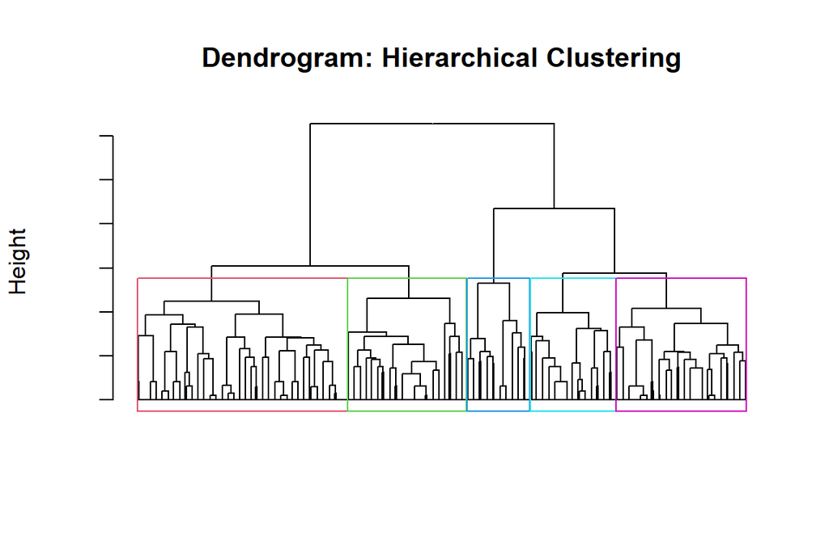

```r
scales.hierarch <- as.data.frame(lungcancer)
distance <- dist(scales.hierarch, method = "euclidean")
hc1 <- hclust(distance, method = "complete")

avg_dend_obj <- as.dendrogram(hc1)
labels_colors(avg_dend_obj) <- "white"
plot(avg_dend_obj, cex = 0.6,
     labels = FALSE,
     hang = -1,
     xlab = "",
     ylab = "Height",
     main = "Dendrogram: Hierarchical Clustering")
rect.hclust(hc1, k = 5, border = 2:9)
```

Instead of choosing the number of clusters, we can use hierarchical clustering to determine the optimal number of clusters. We again see via the elbow plot and silhouette plot that the optimal clusters for our dataset is 2.

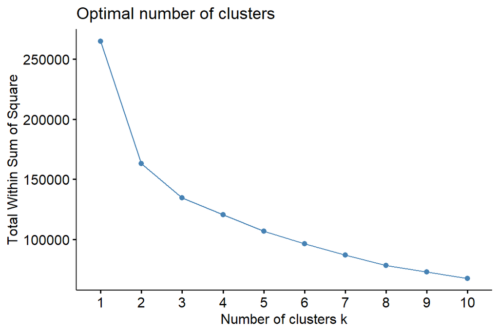

```r
fviz_nbclust(scales.hierarch, FUN = hcut, method = "wss")
```

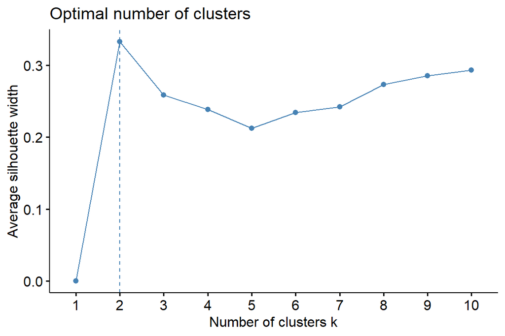

```r
fviz_nbclust(scales.hierarch, FUN = hcut, method = "silhouette")
```

Below we see the visual check of our Hierarchical clustering of ChronicLung and Smoker again utilizing the 2 clusters. We see there is distinct clustering in the top right of the plot, while the other cluster encompasses the remainder of the plot.

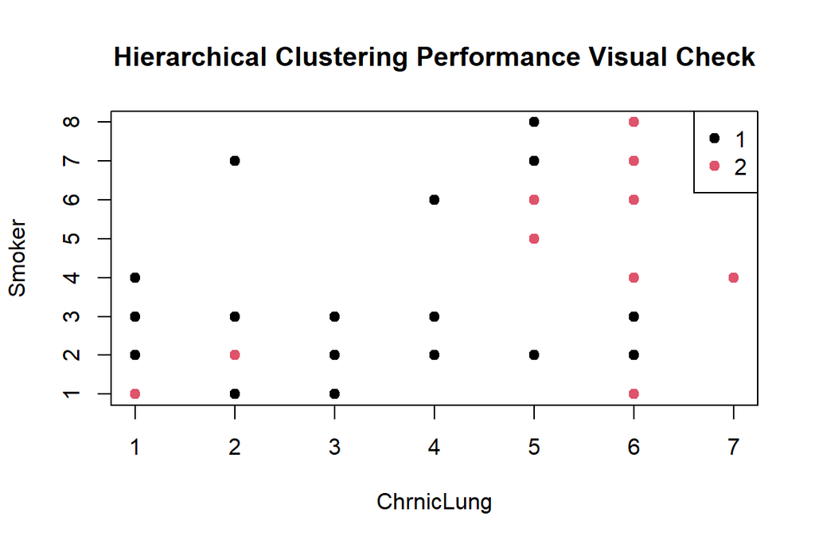

```r
hc8 <- hclust(distance, method = "complete")

group = cutree(hc8, k = 2)

scales.hierarch$group = group

plot(scales.hierarch[, 8], scales.hierarch[, 11],
     pch = 19,
     col = factor(scales.hierarch$group),
     xlab = "ChrnicLung",
     ylab = "Smoker",
     main = "Hierarchical Clustering Performance Visual Check")

legend("topright",
       legend = levels(factor(scales.hierarch$group)),
       pch = 19,
       col = 1:2)
```

## 4.3 Principal Component Analysis (PCA)

The next unsupervised statistical technique we utilized in this analysis was a dimension reduction technique known as Principal Component Analysis (PCA). As discussed in the methodology section above, this is a very popular and effective technique that helps condense the number of variables down into more impactful and meaningful variables while maintaining as much variability as possible.

We can see in the summary readout that the 1st component captures 37.2% of the variation seen in the numeric variables in the dataset. The 2nd component contributes another 10.63% and by including the 3rd component (8.918%) we have a majority (56.744%) of the variation we see in our data is captured in the 1st 3 components. While this may not seem like a significant amount captured, we must remember we started out with 22 variables. By incorporating the top 12 components we result in 90.415% of the total variation.

```r
log.lungcancer <- log(lungcancer[, -c(2, 24)])

lung_pca <- prcomp(log.lungcancer, center = TRUE, scale = TRUE)

kable(summary(lung_pca)$importance, caption="The importance of each principal component")
```

The importance of each principal component

|  | PC1 | PC2 | PC3 | PC4 | PC5 | PC6 | PC7 | PC8 | PC9 | PC10 | PC11 | PC12 | PC13 | PC14 | PC15 | PC16 | PC17 | PC18 | PC19 | PC20 | PC21 | PC22 |
| --- | --- | --- | --- | --- | --- | --- | --- | --- | --- | --- | --- | --- | --- | --- | --- | --- | --- | --- | --- | --- | --- | --- |
| Standard deviation | 2.860598 | 1.529267 | 1.40068 | 1.182444 | 1.064274 | 1.009626 | 0.8934847 | 0.8667175 | 0.8168711 | 0.7799459 | 0.7526703 | 0.6823318 | 0.6438278 | 0.613638 | 0.5724729 | 0.4980518 | 0.4715248 | 0.412328 | 0.3515309 | 0.3365944 | 0.2506925 | 0.2238532 |
| Proportion of Variance | 0.371960 | 0.106300 | 0.08918 | 0.063550 | 0.051490 | 0.046330 | 0.0362900 | 0.0341500 | 0.0303300 | 0.0276500 | 0.0257500 | 0.0211600 | 0.0188400 | 0.017120 | 0.0149000 | 0.0112800 | 0.0101100 | 0.007730 | 0.0056200 | 0.0051500 | 0.0028600 | 0.0022800 |
| Cumulative Proportion | 0.371960 | 0.478260 | 0.56744 | 0.630990 | 0.682470 | 0.728810 | 0.7651000 | 0.7992400 | 0.8295700 | 0.8572200 | 0.8829700 | 0.9041400 | 0.9229800 | 0.940090 | 0.9549900 | 0.9662600 | 0.9763700 | 0.984100 | 0.9897200 | 0.9948700 | 0.9977200 | 1.0000000 |

The next step of the process involved finding the factor loading of the above fitted PCA. Factor loadings represent the correlation that exists between our original variables and the newly created principal components (PCs). They tell us the amount each variable contributes to a particular PC as well as whether it is a positive or inverse relationship based on a scale of -1 to 1.

We see below there were several variables that contributed significantly to PC1 i.e. Alochol, DustAllergy, Occu_Hazard, GeneticRisk, ChronicLung, BalanceDiet, Obesity, ChestPain, CoughBlood, with GeneticRisk contributing the most with 0.31. While GeneticRisk contributes the most, we do see the remaining highest variables displaying a pattern generally of lifestyle and environmental factors which is significant to take note of. Lastly, we see there is no negative factor loadings for PC1 indicating they all have a positive relationship in explaining the variation of lung cancer risk in the dataset. The 2nd PC factor loadings indiate they are more related to not only the lifestyle of the patient i.e. Smoking: 0.40 & PassiveSmoker: 0.24 but as well as the general overall health as we see weightloss, Clubb_Fingers, and ShortBreath has an strong inverse relationship at -0.41, -0.36, and -0.36 respectively.

```r
kable(round(lung_pca$rotation, 2), caption="Factor loadings of the PCA")
```

Factor loadings of the PCA

|  | PC1 | PC2 | PC3 | PC4 | PC5 | PC6 | PC7 | PC8 | PC9 | PC10 | PC11 | PC12 | PC13 | PC14 | PC15 | PC16 | PC17 | PC18 | PC19 | PC20 | PC21 | PC22 |
| --- | --- | --- | --- | --- | --- | --- | --- | --- | --- | --- | --- | --- | --- | --- | --- | --- | --- | --- | --- | --- | --- | --- |
| Age | 0.03 | -0.01 | 0.03 | 0.42 | 0.37 | 0.60 | -0.46 | 0.15 | -0.03 | 0.02 | 0.19 | 0.12 | 0.06 | 0.00 | -0.15 | -0.03 | -0.03 | -0.08 | 0.04 | -0.05 | -0.02 | 0.07 |
| AirPoll | 0.22 | -0.03 | -0.09 | 0.18 | 0.17 | -0.34 | -0.31 | -0.52 | -0.20 | 0.00 | -0.16 | -0.10 | 0.12 | 0.20 | 0.08 | -0.08 | 0.06 | -0.41 | 0.18 | 0.20 | 0.00 | 0.06 |
| Alcohol | 0.29 | -0.01 | -0.16 | 0.08 | -0.09 | 0.15 | -0.01 | -0.02 | -0.29 | -0.13 | 0.12 | -0.22 | -0.21 | -0.01 | 0.29 | 0.07 | -0.34 | 0.01 | -0.41 | 0.13 | 0.40 | -0.31 |
| DustAllergy | 0.27 | -0.12 | 0.02 | -0.16 | 0.09 | -0.03 | 0.13 | -0.08 | -0.10 | -0.32 | 0.41 | 0.33 | -0.07 | 0.08 | 0.06 | -0.32 | 0.32 | -0.07 | 0.16 | -0.39 | 0.12 | -0.22 |
| Occu_Hazard | 0.29 | 0.00 | -0.14 | -0.12 | -0.08 | 0.24 | 0.20 | -0.12 | 0.23 | 0.01 | 0.18 | 0.01 | -0.24 | -0.03 | 0.20 | -0.06 | -0.10 | -0.33 | -0.19 | 0.10 | -0.57 | 0.30 |
| GeneticRisk | 0.31 | -0.06 | -0.21 | -0.05 | -0.09 | 0.03 | -0.02 | -0.11 | 0.07 | 0.01 | -0.03 | -0.06 | 0.10 | -0.39 | -0.04 | 0.17 | 0.04 | 0.08 | 0.08 | -0.27 | 0.42 | 0.61 |
| ChronicLung | 0.26 | 0.09 | -0.19 | 0.03 | -0.06 | 0.28 | 0.04 | -0.25 | 0.32 | 0.25 | -0.17 | 0.04 | -0.09 | -0.12 | 0.03 | -0.15 | 0.28 | 0.34 | 0.27 | 0.34 | 0.08 | -0.32 |
| BalanceDiet | 0.27 | 0.14 | 0.02 | 0.05 | -0.14 | -0.14 | 0.02 | 0.29 | 0.25 | 0.04 | -0.04 | 0.26 | 0.29 | 0.06 | 0.02 | -0.27 | -0.60 | -0.13 | 0.29 | 0.04 | 0.11 | -0.05 |
| Obesity | 0.29 | 0.00 | 0.08 | -0.06 | 0.17 | -0.06 | 0.17 | -0.06 | -0.01 | 0.11 | 0.10 | 0.27 | -0.13 | 0.10 | -0.34 | 0.73 | -0.11 | -0.07 | 0.13 | 0.05 | -0.02 | -0.18 |
| Smoking | 0.18 | 0.40 | -0.04 | 0.02 | -0.22 | -0.02 | -0.22 | 0.29 | -0.29 | 0.15 | -0.13 | -0.04 | 0.03 | -0.19 | 0.36 | 0.22 | 0.22 | -0.08 | 0.20 | -0.28 | -0.27 | -0.17 |
| PassiveSmoker | 0.25 | 0.24 | 0.13 | -0.13 | 0.12 | -0.21 | -0.30 | -0.01 | -0.12 | -0.11 | -0.09 | 0.44 | 0.01 | -0.02 | -0.02 | -0.09 | 0.03 | 0.43 | -0.42 | 0.20 | -0.14 | 0.19 |
| ChestPain | 0.29 | 0.11 | -0.08 | -0.03 | -0.06 | 0.02 | -0.02 | 0.02 | 0.20 | -0.16 | -0.15 | -0.32 | 0.39 | -0.01 | -0.49 | -0.06 | 0.14 | -0.13 | -0.38 | -0.21 | -0.12 | -0.27 |
| CoughBlood | 0.26 | 0.18 | 0.03 | 0.04 | 0.23 | -0.03 | 0.17 | 0.11 | -0.13 | 0.04 | 0.12 | -0.49 | -0.07 | 0.47 | -0.04 | -0.08 | -0.07 | 0.42 | 0.22 | -0.09 | -0.11 | 0.23 |
| Fatigue | 0.18 | -0.02 | 0.41 | 0.07 | 0.27 | 0.08 | 0.28 | 0.25 | 0.15 | 0.10 | -0.36 | 0.04 | 0.06 | 0.16 | 0.31 | 0.02 | 0.30 | -0.25 | -0.20 | 0.06 | 0.27 | 0.11 |
| WeightLoss | 0.14 | -0.41 | 0.15 | -0.15 | 0.39 | -0.11 | -0.10 | -0.05 | -0.01 | 0.26 | -0.27 | -0.11 | -0.20 | -0.34 | 0.03 | -0.16 | -0.27 | 0.11 | 0.00 | -0.32 | -0.18 | -0.19 |
| ShortBreath | 0.21 | -0.36 | -0.02 | -0.05 | 0.00 | -0.13 | 0.02 | 0.47 | -0.24 | -0.16 | 0.11 | -0.16 | 0.03 | -0.29 | -0.16 | -0.06 | 0.18 | -0.06 | 0.17 | 0.52 | -0.09 | 0.04 |
| Wheezing | 0.03 | -0.27 | 0.22 | -0.53 | -0.11 | 0.33 | -0.25 | -0.13 | 0.01 | -0.15 | -0.01 | -0.09 | 0.42 | 0.20 | 0.25 | 0.20 | -0.08 | 0.11 | 0.12 | 0.07 | -0.05 | -0.02 |
| Swallow_Diff | 0.02 | 0.29 | 0.40 | -0.39 | -0.14 | 0.02 | -0.29 | 0.00 | 0.04 | 0.28 | 0.20 | -0.18 | -0.34 | -0.03 | -0.26 | -0.17 | 0.03 | -0.25 | 0.02 | 0.08 | 0.24 | 0.04 |
| Clubb_Fingers | 0.12 | -0.36 | -0.11 | 0.04 | -0.46 | 0.17 | -0.05 | 0.10 | -0.27 | 0.21 | -0.35 | 0.21 | -0.21 | 0.40 | -0.24 | -0.11 | 0.05 | -0.01 | -0.04 | -0.13 | -0.01 | 0.10 |
| FrequentCold | 0.10 | -0.14 | 0.39 | 0.32 | -0.26 | -0.05 | 0.18 | -0.21 | -0.18 | 0.45 | 0.38 | 0.00 | 0.36 | -0.13 | 0.02 | -0.05 | 0.02 | 0.12 | -0.14 | 0.00 | -0.09 | 0.00 |
| DryCough | 0.11 | -0.26 | 0.18 | 0.31 | -0.25 | -0.29 | -0.37 | 0.10 | 0.52 | -0.18 | 0.14 | -0.12 | -0.24 | 0.13 | 0.14 | 0.18 | 0.10 | 0.12 | -0.02 | -0.09 | -0.03 | -0.04 |
| Snoring | 0.05 | 0.13 | 0.48 | 0.22 | -0.19 | 0.20 | 0.16 | -0.24 | -0.14 | -0.52 | -0.29 | -0.05 | -0.17 | -0.22 | -0.12 | -0.02 | -0.14 | 0.04 | 0.21 | 0.00 | -0.10 | 0.03 |

A scree plot is very useful in visualizing how our PC’s explain the total variability in our data. In order to retain the optimal number of PC’s we look for an “elbow” which signifies the amount of variation explained by adding additional PC’s is greatly reduced. We want to keep as much variation as possible with the smallest amount of PC’s possible. However, the one downside of Scree plots is the ambiguous nature of some datasets, in particular larger ones that may have several elbows sort of “mudding” the picture of how many PC’s to keep. We see below the most prominent elbow occuring at PC2, which means we will utilize the first 2 PC’s for any further analysis.

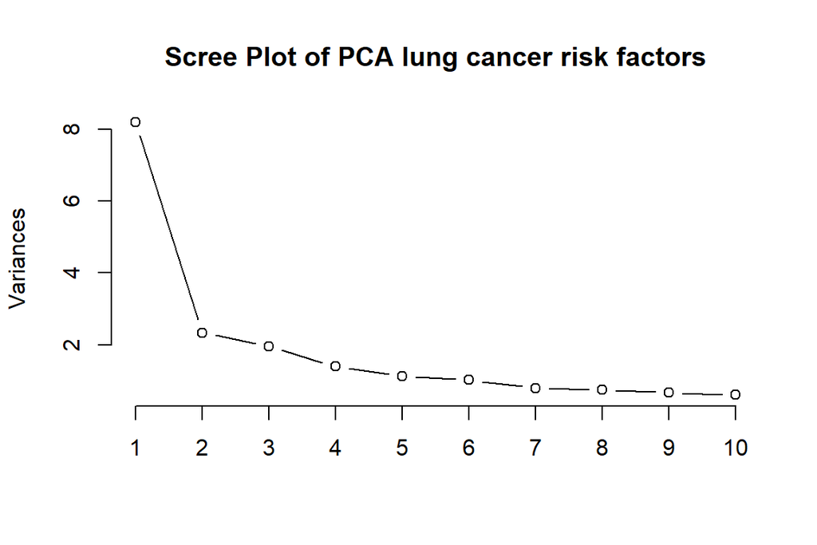

```r
screeplot(lung_pca,
          type = "lines",
          main = "Scree Plot of PCA lung cancer risk factors")
```

We see below the 1st 15 PC scores that were transformed from the original variables. We only need to keep the first 2 PC scores for future analysis, as they retain the most variation within the dataset as previously noted.

```r
kable(lung_pca$x[1:15,], caption = "The first 15 PC scores transformed from the original variables")
```

The first 15 PC scores transformed from the original variables

| PC1 | PC2 | PC3 | PC4 | PC5 | PC6 | PC7 | PC8 | PC9 | PC10 | PC11 | PC12 | PC13 | PC14 | PC15 | PC16 | PC17 | PC18 | PC19 | PC20 | PC21 | PC22 |
| --- | --- | --- | --- | --- | --- | --- | --- | --- | --- | --- | --- | --- | --- | --- | --- | --- | --- | --- | --- | --- | --- |
| -1.922712 | 0.6544902 | 0.5095926 | 0.0720068 | 1.1011095 | -0.1395873 | 0.7982250 | -0.2785313 | -0.1002161 | -0.9160238 | 0.5979675 | -0.5329720 | -1.2054861 | -0.6598164 | 0.6908522 | 0.6899032 | -0.3505359 | -0.2671544 | 0.0096399 | -0.9009986 | 0.0002367 | -0.1923084 |
| -2.461771 | -0.9393062 | -0.2012366 | -2.7554300 | -0.7159253 | -2.1186682 | -1.3155038 | 0.0080528 | 0.4911374 | -1.6460884 | 0.5019856 | -0.6094014 | -0.6177709 | -0.2716309 | 0.0084273 | 0.0180115 | 0.6708243 | 0.4962811 | 0.9184203 | 0.3449003 | -0.4117833 | 0.8747107 |
| 2.157871 | -2.0695804 | 0.3075835 | 1.4691062 | 0.8907927 | -1.0173144 | 1.2180960 | 0.9135713 | 0.3383999 | 0.4051839 | 0.1527747 | -0.1990050 | 0.1438153 | 0.2380964 | 0.2445670 | 0.2495531 | -0.0986684 | 0.2296355 | 0.0445803 | 0.0926427 | -0.0133451 | 0.0385445 |
| 3.416401 | 1.5229722 | 0.4353630 | 1.9798165 | -1.0602162 | -0.6210122 | 0.0513817 | -0.6024716 | 0.0638228 | 0.0832353 | 0.1539669 | 0.2789616 | -0.7572999 | 0.3104269 | -0.4506150 | -0.1508474 | 0.3031223 | -0.0185559 | -0.0556709 | -0.1746534 | -0.1130808 | 0.0413172 |
| 3.021343 | 2.4317723 | -0.6823133 | 1.0574772 | 0.5089925 | -0.1101622 | 0.2140773 | -0.1455981 | -0.6977461 | 0.1551062 | 0.8126660 | 0.1236720 | -0.0583546 | -0.4892739 | -0.5473189 | -0.2132931 | -0.0544213 | -0.2500866 | 0.0444766 | 0.0986778 | 0.0237363 | 0.1499761 |
| 2.157871 | -2.0695804 | 0.3075835 | 1.4691062 | 0.8907927 | -1.0173144 | 1.2180960 | 0.9135713 | 0.3383999 | 0.4051839 | 0.1527747 | -0.1990050 | 0.1438153 | 0.2380964 | 0.2445670 | 0.2495531 | -0.0986684 | 0.2296355 | 0.0445803 | 0.0926427 | -0.0133451 | 0.0385445 |
| -1.875834 | 0.6360098 | 0.5499990 | 0.6435805 | 1.6073715 | 0.6823079 | 0.1743091 | -0.0698628 | -0.1393147 | -0.8923539 | 0.8607231 | -0.3682773 | -1.1257531 | -0.6636673 | 0.4883623 | 0.6546381 | -0.3964293 | -0.3832815 | 0.0677452 | -0.9662610 | -0.0266221 | -0.1005496 |
| -2.742182 | -0.3698764 | 0.7244378 | -0.0722597 | -0.2706736 | -0.7557064 | 0.0904740 | -0.9316004 | 1.3843270 | -0.8106538 | -0.2842650 | 1.6394271 | 0.9177635 | -0.0225670 | -0.1472543 | -0.1057731 | 0.0786025 | -0.3784709 | -0.3339460 | 0.5255972 | -0.1914409 | -0.2891382 |
| 1.316222 | 0.4735157 | -2.1668905 | -0.5866947 | -0.4925042 | -0.7524716 | -1.4102161 | 0.0831636 | -0.0750048 | 0.7779972 | 0.4832793 | 0.3731657 | -0.6082068 | 0.1589277 | -0.7983390 | -0.1245113 | -0.2101744 | 0.4357455 | -0.1680853 | -0.8388823 | -0.2560667 | -0.2814742 |
| -1.773180 | 0.4521110 | -0.1032511 | -0.9759260 | -0.3614828 | 1.5233986 | -0.5111379 | -0.2769618 | -1.5321200 | -1.0538013 | 0.0554109 | -0.2250292 | 0.4844484 | -0.2827973 | -1.7685063 | -0.2884246 | -0.6397465 | 0.5500517 | 0.7826969 | 0.1103251 | 0.4645395 | 0.1038370 |
| 3.166118 | 1.5512308 | 1.1318424 | -0.5696233 | 0.0761987 | 0.4771997 | -1.2351750 | -0.8392094 | 0.6690018 | 0.1048758 | 0.5145261 | -0.0406491 | 0.4687567 | 0.3647737 | 0.5433933 | 0.4557014 | -0.1809820 | -0.1000532 | -0.1110781 | -0.3631298 | 0.2626034 | 0.0402698 |
| 3.659910 | 0.3967054 | 0.3736097 | -0.2892101 | 1.6230871 | 1.9550658 | -0.1060309 | 0.0338722 | -1.3173166 | -0.1153943 | -1.1698085 | 0.6123562 | 1.1914128 | -0.1750387 | 0.3317164 | -0.0404243 | -0.3606764 | -0.2980807 | 0.0717960 | 0.0279853 | -0.1636919 | 0.1478092 |
| 1.863676 | 1.5097730 | 1.8442494 | 0.8123891 | 0.1925590 | -0.0151474 | 0.1695266 | -0.8865616 | 0.5287402 | -0.6484461 | 0.6176081 | -0.1099664 | 0.8675469 | -0.5122202 | 0.7618459 | 0.6224824 | -0.4141264 | 0.2048349 | -0.1862467 | -0.5682520 | -0.4196987 | -0.1199702 |
| 3.355005 | 1.5340172 | 0.4502612 | 1.8291142 | -1.1955873 | -0.6914011 | 0.2433327 | -0.5157915 | 0.1193431 | 0.0786656 | 0.1432747 | 0.2731603 | -0.8015478 | 0.2618511 | -0.4315603 | -0.1257717 | 0.2964995 | 0.1032039 | -0.1093735 | -0.2096117 | -0.1073823 | 0.0089340 |
| -2.619183 | -1.3559141 | -0.7276655 | 0.2308348 | -0.8340812 | -1.1341757 | -0.2033868 | 0.2115599 | 0.5873322 | -0.9839817 | -0.5984673 | 0.4720320 | 0.9395242 | 0.7626079 | -0.4846583 | 0.6375260 | 0.5466095 | -0.1109526 | 0.3539820 | -0.7285835 | -0.2471452 | -0.0483987 |

Lastly, we saved the 1st two PC’s to our dataset and named them appropriately **Lifestyle** and **Health** to support any future analysis.

```r
my.final.lung.data = lungcancer
my.final.lung.data$Lifestyle = lung_pca$x[, 1]
my.final.lung.data$Health = lung_pca$x[, 2]
write.csv(my.final.lung.data, file = "C:\\Users\\frvas\\Desktop\\STA551\\Project 5\\lung_cancer_data.csv")
```

# 5 Anomaly Detection

The last part of our analysis focused on anomaly detection within our dataset which looks for irregular patterns or observations where they’re not expected.

```r
Logistic.model <- glm(Level ~ Age + Gender + AirPoll + Alcohol + DustAllergy + Occu_Hazard + GeneticRisk + ChronicLung + BalanceDiet + Obesity + Smoking + PassiveSmoker + ChestPain + CoughBlood + Fatigue + WeightLoss + ShortBreath + Wheezing + Swallow_Diff + Clubb_Fingers + FrequentCold + DryCough + Snoring,
  data = lungcancer, family = binomial)

lungcancer$Predicted_Prob <- predict(Logistic.model, type="response")
lungcancer_ordered<- lungcancer[order(lungcancer$Predicted_Prob),]
cutoff <- round(0.1 * nrow(lungcancer_ordered))
lungcancer_ordered$Custom_Level <- ifelse(1:nrow(lungcancer_ordered) <= cutoff, "High", "Low")

table(lungcancer_ordered$Custom_Level)
```

```
##
## High  Low
##  100  900
```

## 5.1 Local Outlier Factor (LOF)

The Local Outlier Factor (LOF) is an outlier detection method we utilized for our subsequent analysis. The method identifies outliers via measuring the density of the neighborhood around an observation. Observations that have a significantly different density than the neighborhood they lie in would be considered local outliers.

We used the numerical variables our dataset to calculate the LOF scores for each observation. In order to assess the overall performance of outlier detection with LOF scores, we selected a set of potential LOF cut-off scores and plot the LoF score against the detection improvement rate.

We can see below that LOF scores typically have a highly skewed distribution.

```r
library(dbscan)

lungcancer.new <- lungcancer_ordered

lof_scores <- lof(lungcancer.new[, c(1,3:23)], minPts = 100)

summary(lof_scores)
```

```
##    Min. 1st Qu.  Median    Mean 3rd Qu.    Max.
##  0.9654  0.9950  1.0260  1.0512  1.0884  1.2873
```

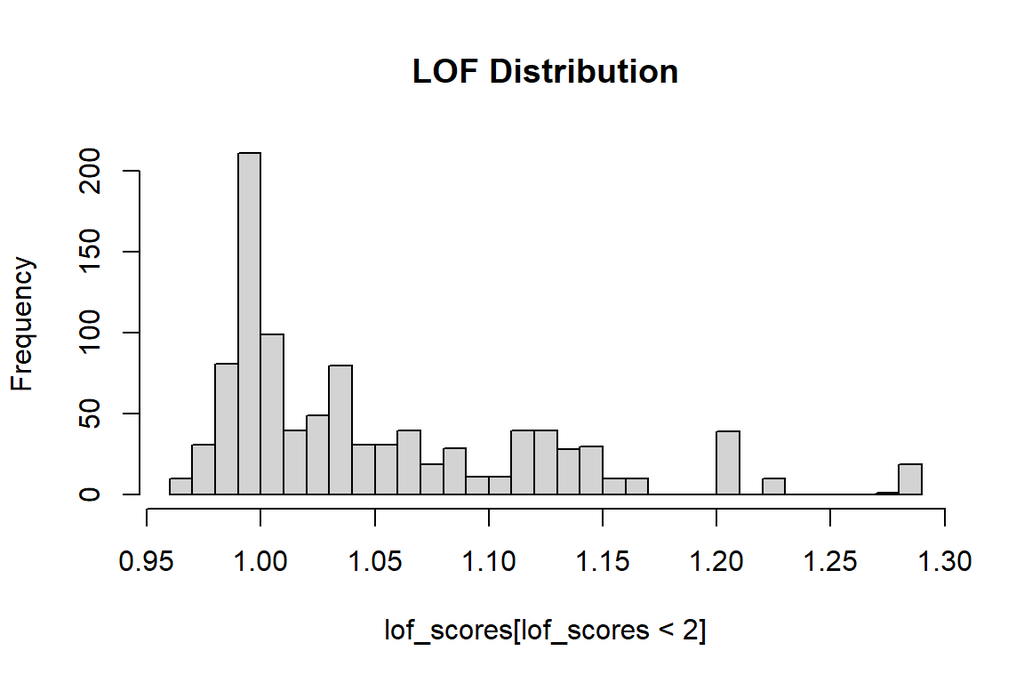

```r
hist(lof_scores[lof_scores < 2], breaks = 25, main = "LOF Distribution")
```

The following figures are a result of plotting the relative improvate rate against the LoF scores to show our performance of detection.

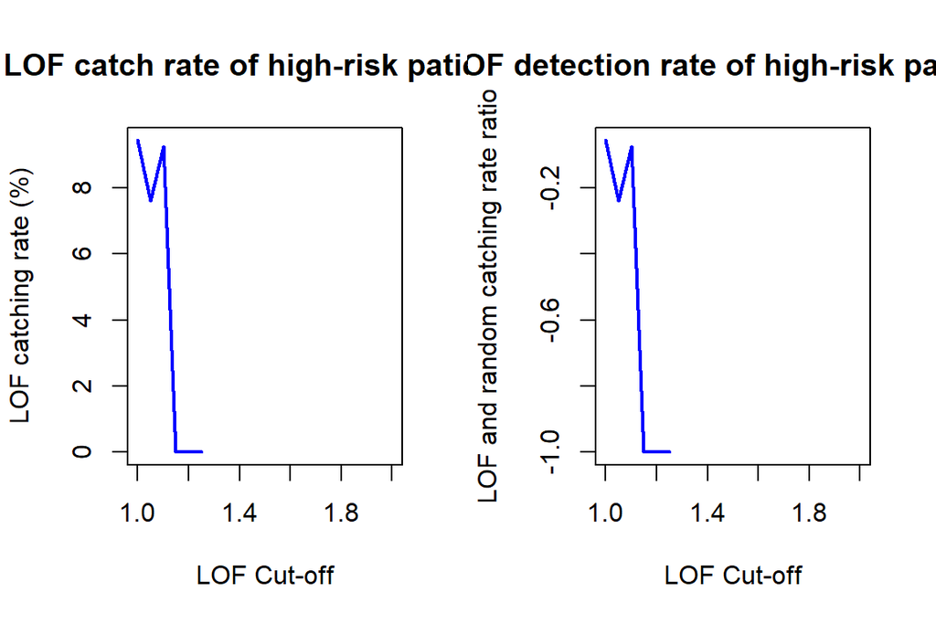

```r
cut.lof = seq(1, 2, length = 21)
lof.catching.rate = NULL

for (i in 1:length(cut.lof)) {
  ID = lof_scores > cut.lof[i]
  isHighRisk = lungcancer.new$Custom_Level[ID] == "High"
  lof.catching.rate[i] = sum(isHighRisk) / sum(ID)}

defaultHighRiskRate = sum(lungcancer.new$Custom_Level == "High") / length(lungcancer.new$Custom_Level)
rel.detect.rate = (lof.catching.rate - defaultHighRiskRate) / defaultHighRiskRate
par(mfrow = c(1, 2))

plot(cut.lof, 100 * lof.catching.rate, type = "l", col = "blue", lwd = 2,
     xlab = "LOF Cut-off",
     ylab = "LOF catching rate (%)",
     main = "LOF catch rate of high-risk patients")

plot(cut.lof, rel.detect.rate, type = "l", col = "blue", lwd = 2,
     xlab = "LOF Cut-off",
     ylab = "LOF and random catching rate ratio",
     main = "LOF detection rate of high-risk patients")
```

However, as expected since we created a Custom_Level variable that where we forced a distribution of 10%/90% we have not created a good model of detection as we can see via the Receiver Operating Characteristic (ROC) curve below which shows our Area Under the Curve (AUC) to be slightly lower than randomly assigning. Therefore, we do not have a good predicting power of LOF scores. The lungcancer dataset with the numeric variables on a scale are not well suited for this type of anomaly detection and we would recommend to avoid this type of outlier detection in future analysis of this dataset.

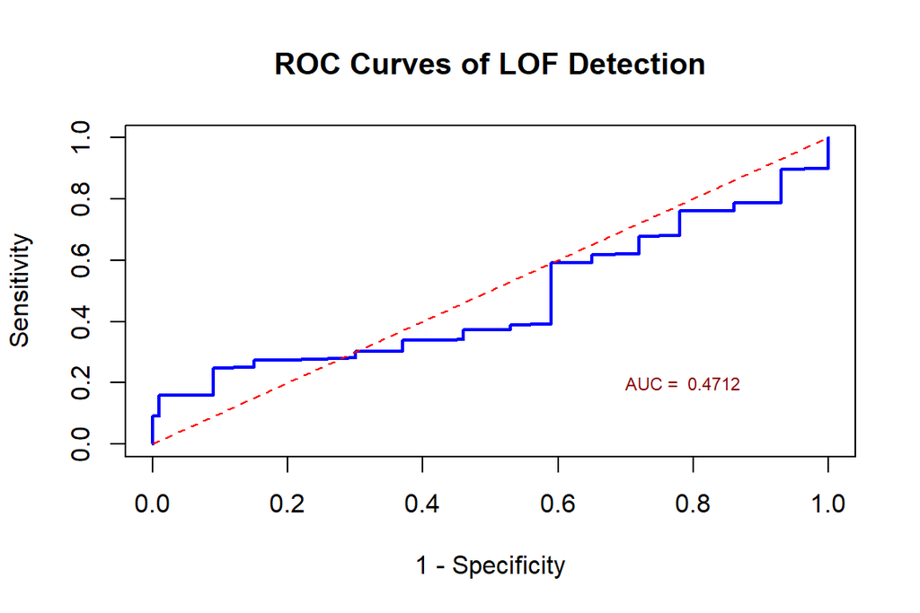

```r
library(pROC)
cut.lof = seq(1, 15, length = 20)

pred.lof.100 = NULL

for (i in 1:length(cut.lof)) {
  pred.lof.100[i] = as.numeric(lof_scores > cut.lof[i])}

category = as.character(lungcancer.new$Custom_Level)
category[category == "High"] <- "1"
category[category == "Low"] <- "0"

ROCobj.lof <- roc(category, lof_scores, levels = c("1", "0"), direction = ">")
sen.LOF = ROCobj.lof$sensitivities
fnr.LOF = 1 - ROCobj.lof$specificities

par(type = "s")
plot(fnr.LOF, sen.LOF, type = "l", lwd = 2, col = "blue",
     xlim = c(0, 1), ylim = c(0, 1),
     xlab = "1 - Specificity",
     ylab = "Sensitivity",
     main = "ROC Curves of LOF Detection")

segments(0, 0, 1, 1, lwd = 1, col = "red", lty = 2)

AUC = ROCobj.lof$auc
text(0.87, 0.20, paste("AUC = ", round(AUC, 4)), col = "darkred", cex = 0.7, adj = 1)
```

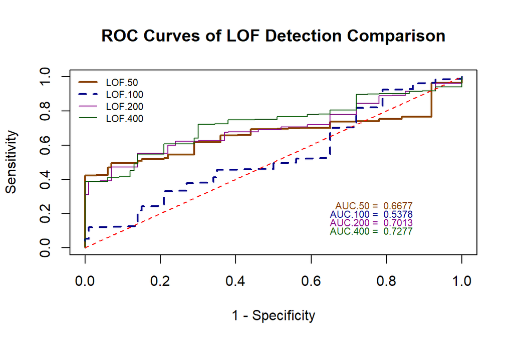

```r
library(dbscan)
library(pROC)
category = as.character(lungcancer.new$Custom_Level)
category[category == "High"] <- 1
category[category == "Low"] <- 0
category <- as.numeric(category)

lof.lungcancer.50  <- lof(lungcancer.new[, c(1, 3, 4, 5, 6)], minPts = 50)
lof.lungcancer.100 <- lof(lungcancer.new[, c(1, 3, 4, 5, 6)], minPts = 100)
lof.lungcancer.200 <- lof(lungcancer.new[, c(1, 3, 4, 5, 6)], minPts = 200)
lof.lungcancer.400 <- lof(lungcancer.new[, c(1, 3, 4, 5, 6)], minPts = 400)

ROCobj.lof.50  <- roc(category, lof.lungcancer.50, levels=c(1, 0), direction = ">")
ROCobj.lof.100 <- roc(category, lof.lungcancer.100, levels=c(1, 0), direction = ">")
ROCobj.lof.200 <- roc(category, lof.lungcancer.200, levels=c(1, 0), direction = ">")
ROCobj.lof.400 <- roc(category, lof.lungcancer.400, levels=c(1, 0), direction = ">")

sen.LOF.50  = ROCobj.lof.50$sensitivities
fnr.LOF.50  = 1 - ROCobj.lof.50$specificities
sen.LOF.100 = ROCobj.lof.100$sensitivities
fnr.LOF.100 = 1 - ROCobj.lof.100$specificities
sen.LOF.200 = ROCobj.lof.200$sensitivities
fnr.LOF.200 = 1 - ROCobj.lof.200$specificities
sen.LOF.400 = ROCobj.lof.400$sensitivities
fnr.LOF.400 = 1 - ROCobj.lof.400$specificities

par(type = "s")
colors = c("#8B4500", "#00008B", "#8B008B", "#055d03")

plot(fnr.LOF.50, sen.LOF.50, type = "l", lwd = 2, col = colors[1],
     xlim = c(0, 1), ylim = c(0, 1),
     xlab = "1 - Specificity",
     ylab = "Sensitivity",
     main = "ROC Curves of LOF Detection Comparison")
lines(fnr.LOF.100, sen.LOF.100, lwd = 2, lty = 2, col = colors[2])
lines(fnr.LOF.200, sen.LOF.200, lwd = 1, col = colors[3])
lines(fnr.LOF.400, sen.LOF.400, lwd = 1, col = colors[4])

segments(0, 0, 1, 1, lwd = 1, col = "red", lty = 2)

legend("topleft", c("LOF.50", "LOF.100", "LOF.200", "LOF.400"),
       col = colors, lwd = c(2, 2, 1, 1),
       lty = c(1, 2, 1, 1), bty = "n", cex = 0.7)

AUC.50  = ROCobj.lof.50$auc
AUC.100 = ROCobj.lof.100$auc
AUC.200 = ROCobj.lof.200$auc
AUC.400 = ROCobj.lof.400$auc

text(0.87, 0.25, paste("AUC.50 = ", round(AUC.50, 4)), col = colors[1], cex = 0.7, adj = 1)
text(0.87, 0.20, paste("AUC.100 = ", round(AUC.100, 4)), col = colors[2], cex = 0.7, adj = 1)
text(0.87, 0.15, paste("AUC.200 = ", round(AUC.200, 4)), col = colors[3], cex = 0.7, adj = 1)
text(0.87, 0.10, paste("AUC.400 = ", round(AUC.400, 4)), col = colors[4], cex = 0.7, adj = 1)
```